# Prediction of the Exercise Manner Using the Weight Lifting Exercises Dataset

### Introduction

The weight lifting exercises research (1) collected exericises data of six young healthy participants who were asked to perform the unilateral dumbbell biceps curl in five different manners: “exactly according to the specification (Class A), throwing the elbows to the front (Class B), lifting the dumbbell only halfway (Class C), lowering the dumbbell only halfway (Class D) and throwing the hips to the front (Class E)”(1). The goal of this work is to predict the exercises manner in the weight lifting exercises dataset.

### Exploratory Data Analysis

The whole dataset include 19622 observations of 160 variables. Out of the 160 variables, there are 152 variabels recording three-axes acceleratin, gyroscope and magnetometer data at the users’ glove, armband, lumbar belt, and bumbbell. A first look at the 152 variables found that there are 99 variables where ~98% of the observations are NA values. We thus decide to use the other 53 variables (shown in the following embedded R code chunk) in predicting the execise manner.

```
##  [1] "user_name"            "roll_belt"            "pitch_belt"
##  [4] "yaw_belt"             "total_accel_belt"     "gyros_belt_x"
##  [7] "gyros_belt_y"         "gyros_belt_z"         "accel_belt_x"
## [10] "accel_belt_y"         "accel_belt_z"         "magnet_belt_x"
## [13] "magnet_belt_y"        "magnet_belt_z"        "roll_arm"
## [16] "pitch_arm"            "yaw_arm"              "total_accel_arm"
## [19] "gyros_arm_x"          "gyros_arm_y"          "gyros_arm_z"
## [22] "accel_arm_x"          "accel_arm_y"          "accel_arm_z"
## [25] "magnet_arm_x"         "magnet_arm_y"         "magnet_arm_z"
## [28] "roll_dumbbell"        "pitch_dumbbell"       "yaw_dumbbell"
## [31] "total_accel_dumbbell" "gyros_dumbbell_x"     "gyros_dumbbell_y"
## [34] "gyros_dumbbell_z"     "accel_dumbbell_x"     "accel_dumbbell_y"
## [37] "accel_dumbbell_z"     "magnet_dumbbell_x"    "magnet_dumbbell_y"
## [40] "magnet_dumbbell_z"    "roll_forearm"         "pitch_forearm"
## [43] "yaw_forearm"          "total_accel_forearm"  "gyros_forearm_x"
## [46] "gyros_forearm_y"      "gyros_forearm_z"      "accel_forearm_x"
## [49] "accel_forearm_y"      "accel_forearm_z"      "magnet_forearm_x"
## [52] "magnet_forearm_y"     "magnet_forearm_z"
```

### Random Forest Prediction

We split the dataset into training and test sets with ratio of 6:4 for cross-validation. we first performed the random forest model with 200 trees on the training set.

```r
library(randomForest)
library(caret)
inTrain <- createDataPartition(y=training$classe,p=0.6,list=FALSE)
trains <- training[inTrain,]
tests <- training[-inTrain,]
modelfit1<- randomForest(classe~.,data=trains[,c(features,'classe')],
                    ntree=200,importance=TRUE,proximity=TRUE)
print(modelfit1)
```

```
##
## Call:
##  randomForest(formula = classe ~ ., data = trains[, c(features,      "classe")], ntree = 200, importance = TRUE, proximity = TRUE)
##                Type of random forest: classification
##                      Number of trees: 200
## No. of variables tried at each split: 7
##
##         OOB estimate of  error rate: 0.7%
## Confusion matrix:
##      A    B    C    D    E class.error
## A 3345    2    1    0    0   0.0008961
## B   15 2252   12    0    0   0.0118473
## C    0   15 2034    5    0   0.0097371
## D    0    0   21 1907    2   0.0119171
## E    0    0    4    6 2155   0.0046189
```

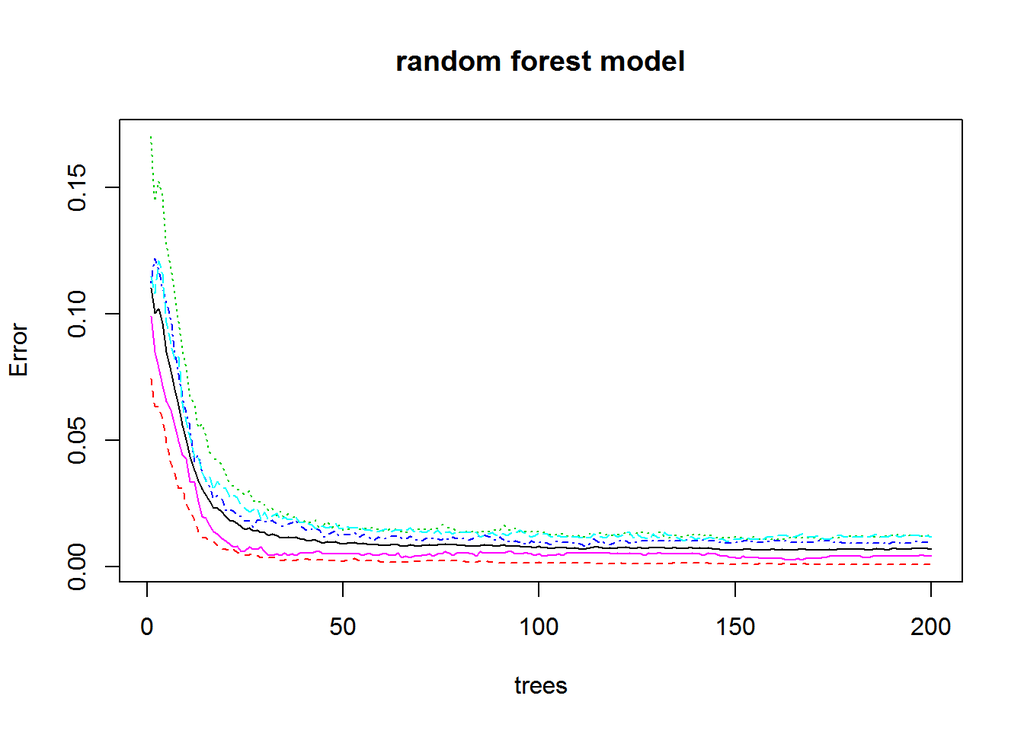

```r
plot(modelfit1, main='random forest model')
```

The following are the top 15 important variables in the random forest model.

```r
features[order(varUsed(modelfit1),decreasing=TRUE)[1:15]]
```

```
##  [1] "yaw_belt"          "pitch_belt"        "roll_belt"
##  [4] "magnet_dumbbell_z" "magnet_dumbbell_y" "magnet_dumbbell_x"
##  [7] "pitch_forearm"     "roll_forearm"      "magnet_forearm_z"
## [10] "magnet_belt_z"     "magnet_belt_x"     "accel_dumbbell_z"
## [13] "roll_dumbbell"     "accel_dumbbell_y"  "accel_forearm_x"
```

We then evaluted the model on the test set. According to refernce (1), we expect the overall performance accuracy is ~98%. Our result shows that the accuracy on the test set is 99%.

```r
pds1 <- predict(modelfit1,tests[,c(features,'classe')])
confusionM <-table(pds1,tests$classe)
# Compare the prediced result with the real classification data
confusionM
```

```
##
## pds1    A    B    C    D    E
##    A 2229    7    0    0    0
##    B    2 1507    3    0    0
##    C    0    4 1362   20    1
##    D    0    0    3 1265    6
##    E    1    0    0    1 1435
```

```r
# the accuracy
sum(diag(confusionM))/sum(confusionM)
```

```
## [1] 0.9939
```

### References

1. Velloso, E.; Bulling, A.; Gellersen, H.; Ugulino, W.; Fuks, H. Qualitative Activity Recognition of Weight Lifting Exercises. Proceedings of 4th International Conference in Cooperation with SIGCHI (Augmented Human ’13) . Stuttgart, Germany: ACM SIGCHI, 2013.